# Pixar Movie data visualisation

This notebook is derived from the guided project in [DataQuest.io](https://www.dataquest.io/). In this notebook, I will go through the data visualisation of pixar's movie and see what insight I can develop in this dataset by using ipython notebook.

The part of rating in this dataset is from [Alex Albright](https://github.com/apalbright)'s [GitHub repo](https://github.com/apalbright/Pixar/blob/master/Pixar.csv). Please visit her great [website](https://thelittledataset.com/) to find more data-driven projects including the visualisation of this dataset via R [here](https://thelittledataset.com/2015/06/30/the-multidimensional-success-of-pixar-films-visualized/). The other parts of data like opening weekend, gross, etc, are gathered by Dataquest.io from [Box Office Mojo](http://www.boxofficemojo.com/).

This notebook is a practice of what I know and also a note for myself to review in the future in case I forget anything. So in the most of steps, I will add a markdown to illustrate the step and maybe some relavent information, and might make the notebook looks tedious. I might build another cleaning version later.

Please feel free to send me a message via james.lee.yichan@gmail.com if you have any comment, suggestion, etc..

### Step 1: import useful packages

#### Pandas

Pandas is a useful tool for data management and data structure. Its most important object is Dataframe which equipped with a bunch of methods for manipulating and exploring structured data.  
[Here is a 10 minutes tutorial for pandas.](http://pandas.pydata.org/pandas-docs/stable/10min.html)

#### Numpy

[Numpy](http://www.numpy.org/) is a poweful tool making python able to deal with n-dim array.

#### Matplotlib

Matplotlib is a python plotting library. Its pyplot interface is Matlab-like. It contains both easy-to-use interface and step-by-step drawing methods.  
[Here is its beginner guide](http://matplotlib.org/users/beginner.html)

#### Seaborn

It's also a plotting tool based on matplotlib. It's interface is very simple to use and also the theme of most of graph is well tuned, which means people like me having no sense of beauty don't need to worry about how to match the color, ratio, etc. to make a nice bar chart. I comment it so we can keep the original style of matplotlib and so readers can see the difference.  
**Two important notes:**

1. After import seaborn, the default plotsetting of matplotlib will be overwrote. In other words, even you call a plot method of matplotlib but not from seaborn, the format of plot is still not the original matplot setting.
2. Outliers of box plot from matplotlib are disapear if I import seaborn. I will discuss more details later.

#### Requests

A package helps us to access the content of website such as html source file or API. Click [Here](http://docs.python-requests.org/en/master/) for detail.

#### beautifulsoup4

A package helps us extracting the data we need from html files. [Here](https://www.crummy.com/software/BeautifulSoup/bs4/doc/) for more information. **Important note:** The package name used for import is bs4 instead of beautiful-soup or beautifulsoup4. I haven't figured out the reason.

```python
import pandas as pd

import numpy as np

import matplotlib.pyplot as plt
# import seaborn as sns

import requests
import bs4

%matplotlib inline

import os
```

### Step 2: Read the CSV file

pandas.read_csv reads Comma-separated values (CSV) file into a Dataframe object. [Here](http://pandas.pydata.org/pandas-docs/stable/generated/pandas.DataFrame.html) for more detail about Dataframe object.

```python
pixar_movies = pd.read_csv("data/PixarMovies.csv")
```

### Step 3: A quick survey of data

Dataframe.shape gives the number of rows and columns of the dataframe.  
(15, 16) here means there are 15 movies in the data and 16 features about these movies

```python
pixar_movies.shape
```

```
(15, 16)
```

Dataframe.dtypes to me is quite useful. It returns the column name and their datatype. So I can clear see what features this data has. So in pixar_movies, there are int, float and object data. String will be shown as object instead of str.

```python
pixar_movies.dtypes
```

```
Year Released                int64
Movie                       object
Length                       int64
RT Score                     int64
IMDB Score                 float64
Metacritic Score             int64
Opening Weekend            float64
Worldwide Gross            float64
Domestic Gross             float64
Adjusted Domestic Gross    float64
International Gross        float64
Domestic %                  object
International %             object
Production Budget            int64
Oscars Nominated           float64
Oscars Won                 float64
dtype: object
```

If I want see more clearly, I would use Dataframe.head() to see the first few rows of data. [Here](http://pandas.pydata.org/pandas-docs/stable/generated/pandas.DataFrame.describe.html) is its documentation.

```python
pixar_movies.head()
```

|  | Year Released | Movie | Length | RT Score | IMDB Score | Metacritic Score | Opening Weekend | Worldwide Gross | Domestic Gross | Adjusted Domestic Gross | International Gross | Domestic % | International % | Production Budget | Oscars Nominated | Oscars Won |
| --- | --- | --- | --- | --- | --- | --- | --- | --- | --- | --- | --- | --- | --- | --- | --- | --- |
| 0 | 1995 | Toy Story | 81 | 100 | 8.3 | 92 | 29.14 | 362.0 | 191.8 | 356.21 | 170.2 | 52.98% | 47.02% | 30 | 3.0 | 0.0 |
| 1 | 1998 | A Bug's Life | 96 | 92 | 7.2 | 77 | 33.26 | 363.4 | 162.8 | 277.18 | 200.6 | 44.80% | 55.20% | 45 | 1.0 | 0.0 |
| 2 | 1999 | Toy Story 2 | 92 | 100 | 7.9 | 88 | 57.39 | 485.0 | 245.9 | 388.43 | 239.2 | 50.70% | 49.32% | 90 | 1.0 | 0.0 |
| 3 | 2001 | Monsters, Inc. | 90 | 96 | 8.1 | 78 | 62.58 | 528.8 | 255.9 | 366.12 | 272.9 | 48.39% | 51.61% | 115 | 3.0 | 1.0 |
| 4 | 2003 | Finding Nemo | 104 | 99 | 8.2 | 90 | 70.25 | 895.6 | 339.7 | 457.46 | 555.9 | 37.93% | 62.07% | 94 | 4.0 | 1.0 |

Another quick survey method, especially useful for numeric type of data, is Dataframe.describe().

```python
pixar_movies.describe()
```

|  | Year Released | Length | RT Score | IMDB Score | Metacritic Score | Opening Weekend | Worldwide Gross | Domestic Gross | Adjusted Domestic Gross | International Gross | Production Budget | Oscars Nominated | Oscars Won |
| --- | --- | --- | --- | --- | --- | --- | --- | --- | --- | --- | --- | --- | --- |
| count | 15.000000 | 15.000000 | 15.000000 | 15.000000 | 15.000000 | 15.000000 | 15.000000 | 15.000000 | 15.000000 | 15.000000 | 15.000000 | 14.000000 | 14.000000 |
| mean | 2006.066667 | 101.533333 | 89.333333 | 7.846667 | 82.800000 | 67.990667 | 612.486667 | 258.506667 | 318.448000 | 353.986667 | 133.400000 | 2.857143 | 0.785714 |
| std | 5.933761 | 9.927355 | 16.451950 | 0.655599 | 12.119642 | 23.270468 | 190.193934 | 66.518284 | 73.321064 | 135.061615 | 59.696614 | 2.032700 | 0.801784 |
| min | 1995.000000 | 81.000000 | 39.000000 | 6.300000 | 57.000000 | 29.140000 | 362.000000 | 162.800000 | 194.430000 | 170.200000 | 30.000000 | 0.000000 | 0.000000 |
| 25% | 2002.000000 | 96.000000 | 85.000000 | 7.300000 | 75.000000 | 58.755000 | 503.150000 | 215.100000 | 261.350000 | 256.050000 | 91.000000 | 1.000000 | 0.000000 |
| 50% | 2007.000000 | 102.000000 | 96.000000 | 8.000000 | 88.000000 | 66.300000 | 559.900000 | 245.900000 | 318.900000 | 336.600000 | 150.000000 | 3.000000 | 1.000000 |
| 75% | 2010.500000 | 109.000000 | 98.500000 | 8.300000 | 92.000000 | 76.450000 | 704.200000 | 280.750000 | 361.165000 | 427.800000 | 182.500000 | 4.750000 | 1.000000 |
| max | 2015.000000 | 116.000000 | 100.000000 | 8.800000 | 96.000000 | 110.310000 | 1063.200000 | 415.000000 | 457.460000 | 648.200000 | 200.000000 | 6.000000 | 2.000000 |

The count value returns number of non-NaN data in the column. Because there is 15 movies in this dataset, most count values are 15 except Oscar Nominated and Oscar Won. We can use pixar_movies["Oscars Nominated"] to access the column Oscars Nominated.  
Each column of Dataframe is a pandas.Series object. [Here](http://pandas.pydata.org/pandas-docs/stable/generated/pandas.Series.html) is its documentation.

```python
pixar_movies["Oscars Nominated"]
```

```
0     3.0
1     1.0
2     1.0
3     3.0
4     4.0
5     4.0
6     2.0
7     5.0
8     6.0
9     5.0
10    5.0
11    0.0
12    1.0
13    0.0
14    NaN
Name: Oscars Nominated, dtype: float64
```

To see which movie with NaN in Oscar Nominated column, assuming the dataset is large and we don't want to find it by eye, we can use pixar_movies[pixar_movies["Oscars Nominated"].isnull()]. pandas.Series.isnull() returns a Series with boolean variable (True/False) in it. There are many ways to select rows of a Dataframe object, and one of them is using boolean array. For more detail about selecting data see [here](http://pandas.pydata.org/pandas-docs/stable/indexing.html).

```python
pixar_movies[pixar_movies["Oscars Nominated"].isnull()]
```

|  | Year Released | Movie | Length | RT Score | IMDB Score | Metacritic Score | Opening Weekend | Worldwide Gross | Domestic Gross | Adjusted Domestic Gross | International Gross | Domestic % | International % | Production Budget | Oscars Nominated | Oscars Won |
| --- | --- | --- | --- | --- | --- | --- | --- | --- | --- | --- | --- | --- | --- | --- | --- | --- |
| 14 | 2015 | Inside Out | 102 | 98 | 8.8 | 93 | 90.4 | 677.1 | 340.5 | 340.5 | 336.6 | 50.29% | 49.71% | 175 | NaN | NaN |

Since this data was established before Oscar 2015, so Inside Out has no Oscar related data by the time.

#### What did I find from a quick survey?

- There are 16 features in this dataset:
  - Year Released
  - Movie name
  - Length of movie (in mins)
  - Score on [Rotten Tomatoes](https://www.rottentomatoes.com/) (out of 100)
  - Score on [IMDb](http://www.imdb.com/) (out of 10)
  - Score on [Metacritic](http://www.metacritic.com/) (out of 100)
  - Opening Weekend (The weekend box office for the initial week of release)
  - Worldwide Gross
  - Domestic Gross
  - Adjusted Domestic Gross ([Adjusted for for Ticket Price Inflation](http://www.boxofficemojo.com/alltime/adjusted.htm))
  - International Gross
  - Domestic %
  - International %
  - Production Budget
  - number of Oscars Nominations (Maximum is 6)
  - number of Oscars Awards (Maximum is 2)
- the data of Dometic % and International % are numeric but their data types are string with a % suffixed.
- Production Budget and Opening Weekend were not adjusted by inflation rates.
- Inside Out has no Oscar related data.

### Step 4: Questions

Before I do any modification, I would like to write down what questions this dataset might be able to answer.

1. What is the trend of Pixar movies in scores, income gross, budget?
2. Which movie is most profitable?
3. What is the trend in the portion of domestic gross and international gross?
4. Is there any relation between Oscars Nominations and other features?

Some of these questions might be irrelavent, but I put it down as a record of brainstorm.

### Step 5: Data cleansing

Before extracting any information from a dataset, I need to check the data quality. For example, if I want to plot a figure of Domestic gross percentage, I need to remove the suffix % and convert their types from string to float. I also need to get the Adjusted Opening Weekend and Adjusted Production Budget if I want to compare them between different Pixar's movies. [Here](https://en.wikipedia.org/wiki/Data_cleansing) is the wiki page about data cleansing.

#### Data conversion

I first remove the suffix % of each string in column Domestic % by using method str followed by [rstrip](http://pandas.pydata.org/pandas-docs/stable/generated/pandas.Series.str.rstrip.html). Then I concatenated its output with method astype to convert string to float.

```python
pixar_movies["Domestic %"] = pixar_movies["Domestic %"].str.rstrip("%").astype(float)
```

I check this column to see if it really is something I want

```python
pixar_movies["Domestic %"]
```

```
0     52.98
1     44.80
2     50.70
3     48.39
4     37.93
5     41.40
6     52.84
7     33.09
8     42.93
9     40.07
10    39.03
11    34.20
12    44.03
13    36.11
14    50.29
Name: Domestic %, dtype: float64
```

And do the same strip and conversion to column International %

```python
pixar_movies["International %"] = pixar_movies["International %"].str.rstrip("%").astype(float)
```

And again, checking the whole dataset is what I expect.

```python
pixar_movies
```

|  | Year Released | Movie | Length | RT Score | IMDB Score | Metacritic Score | Opening Weekend | Worldwide Gross | Domestic Gross | Adjusted Domestic Gross | International Gross | Domestic % | International % | Production Budget | Oscars Nominated | Oscars Won |
| --- | --- | --- | --- | --- | --- | --- | --- | --- | --- | --- | --- | --- | --- | --- | --- | --- |
| 0 | 1995 | Toy Story | 81 | 100 | 8.3 | 92 | 29.14 | 362.0 | 191.8 | 356.21 | 170.2 | 52.98 | 47.02 | 30 | 3.0 | 0.0 |
| 1 | 1998 | A Bug's Life | 96 | 92 | 7.2 | 77 | 33.26 | 363.4 | 162.8 | 277.18 | 200.6 | 44.80 | 55.20 | 45 | 1.0 | 0.0 |
| 2 | 1999 | Toy Story 2 | 92 | 100 | 7.9 | 88 | 57.39 | 485.0 | 245.9 | 388.43 | 239.2 | 50.70 | 49.32 | 90 | 1.0 | 0.0 |
| 3 | 2001 | Monsters, Inc. | 90 | 96 | 8.1 | 78 | 62.58 | 528.8 | 255.9 | 366.12 | 272.9 | 48.39 | 51.61 | 115 | 3.0 | 1.0 |
| 4 | 2003 | Finding Nemo | 104 | 99 | 8.2 | 90 | 70.25 | 895.6 | 339.7 | 457.46 | 555.9 | 37.93 | 62.07 | 94 | 4.0 | 1.0 |
| 5 | 2004 | The Incredibles | 115 | 97 | 8.0 | 90 | 70.47 | 631.4 | 261.4 | 341.28 | 370.0 | 41.40 | 58.60 | 92 | 4.0 | 2.0 |
| 6 | 2006 | Cars | 116 | 74 | 7.2 | 73 | 60.12 | 462.0 | 244.1 | 302.59 | 217.9 | 52.84 | 47.16 | 70 | 2.0 | 0.0 |
| 7 | 2007 | Ratatouille | 111 | 96 | 8.0 | 96 | 47.00 | 623.7 | 206.4 | 243.65 | 417.3 | 33.09 | 66.91 | 150 | 5.0 | 1.0 |
| 8 | 2008 | WALL-E | 97 | 96 | 8.4 | 94 | 63.10 | 521.3 | 223.8 | 253.11 | 297.5 | 42.93 | 57.07 | 180 | 6.0 | 1.0 |
| 9 | 2009 | Up | 96 | 98 | 8.3 | 88 | 68.11 | 731.3 | 293.0 | 318.90 | 438.3 | 40.07 | 59.93 | 175 | 5.0 | 2.0 |
| 10 | 2010 | Toy Story 3 | 103 | 99 | 8.4 | 92 | 110.31 | 1063.2 | 415.0 | 423.88 | 648.2 | 39.03 | 60.97 | 200 | 5.0 | 2.0 |
| 11 | 2011 | Cars 2 | 113 | 39 | 6.3 | 57 | 109.00 | 559.9 | 191.5 | 194.43 | 368.4 | 34.20 | 65.80 | 200 | 0.0 | 0.0 |
| 12 | 2012 | Brave | 100 | 78 | 7.2 | 69 | 66.30 | 539.0 | 237.3 | 243.39 | 301.7 | 44.03 | 55.97 | 185 | 1.0 | 1.0 |
| 13 | 2013 | Monsters University | 107 | 78 | 7.4 | 65 | 82.43 | 743.6 | 268.5 | 269.59 | 475.1 | 36.11 | 63.89 | 200 | 0.0 | 0.0 |
| 14 | 2015 | Inside Out | 102 | 98 | 8.8 | 93 | 90.40 | 677.1 | 340.5 | 340.50 | 336.6 | 50.29 | 49.71 | 175 | NaN | NaN |

#### Number rescaling

As I plan to consider the average score pixar movies have among the three review website, I have to make sure that they have same weight when I average them. Clearly, IMDB uses a score out of 10 which will have a smaller weight than the other two if I apply it directly. I have to rescale it to a score out of 100. Since pandas can compute in a vectorized way, I can simply get the rescale score by simply muliply the column with 10.

```python
pixar_movies["IMDB Score"] = pixar_movies["IMDB Score"] * 10
```

#### NaN checking

Assume that the data set is very big and I would like to see if there is any missing data in it. One way to find it out is using [isnull()](http://pandas.pydata.org/pandas-docs/stable/generated/pandas.DataFrame.isnull.html) and followed by [any(axis=1)](http://pandas.pydata.org/pandas-docs/stable/generated/pandas.Series.any.html). I set the parameter axis=1 to let it check row by row instead of column by column. By doing so, pixar_movies[pixar_movies.isnull().any(axis=1)] will return rows containg NaN values. In our particular case, only Inside Out has NaN value due to Oscars Awards.

```python
pixar_movies[pixar_movies.isnull().any(axis=1)]
```

|  | Year Released | Movie | Length | RT Score | IMDB Score | Metacritic Score | Opening Weekend | Worldwide Gross | Domestic Gross | Adjusted Domestic Gross | International Gross | Domestic % | International % | Production Budget | Oscars Nominated | Oscars Won |
| --- | --- | --- | --- | --- | --- | --- | --- | --- | --- | --- | --- | --- | --- | --- | --- | --- |
| 14 | 2015 | Inside Out | 102 | 98 | 88.0 | 93 | 90.4 | 677.1 | 340.5 | 340.5 | 336.6 | 50.29 | 49.71 | 175 | NaN | NaN |

Since these NaNs won't affect most of analyses I plan to do, I would keep them in mind and leave them in the dataset.

#### Consistency checking

Another thing I can check is the consistency of data. That is checking if the data is reasonable in their values, relations, or other relevant properties. For instance I can go back to see if the max and min of Score columns are really between 0 and 100. This might be checked when we do a quick survey by describe() method. Here I want to check if the sum of Domestic % and Internation % are 100%.

```python
pixar_movies[(pixar_movies["Domestic %"] + pixar_movies["International %"] != 100)]
```

|  | Year Released | Movie | Length | RT Score | IMDB Score | Metacritic Score | Opening Weekend | Worldwide Gross | Domestic Gross | Adjusted Domestic Gross | International Gross | Domestic % | International % | Production Budget | Oscars Nominated | Oscars Won |
| --- | --- | --- | --- | --- | --- | --- | --- | --- | --- | --- | --- | --- | --- | --- | --- | --- |
| 2 | 1999 | Toy Story 2 | 92 | 100 | 79.0 | 88 | 57.39 | 485.0 | 245.9 | 388.43 | 239.2 | 50.7 | 49.32 | 90 | 1.0 | 0.0 |

It turns out that there the sum for Toy Story 2 is 100.02%. Since the portions are derived from columns International Gross and Domestic Gross, and the sum of these two should equal Worldwide Gross, let me check if these three columns consistent.

Since they are float, the value might not be exactly the same, so I set a value eps as a accuracy cutoff here. I consider two floats are equal if there difference is smaller than eps.

```python
eps = 1e-12
cond = ((pixar_movies["Domestic Gross"] + pixar_movies["International Gross"]) -
        pixar_movies["Worldwide Gross"]).abs() > eps
inconsis_Gross = pixar_movies[cond]
inconsis_Gross
```

|  | Year Released | Movie | Length | RT Score | IMDB Score | Metacritic Score | Opening Weekend | Worldwide Gross | Domestic Gross | Adjusted Domestic Gross | International Gross | Domestic % | International % | Production Budget | Oscars Nominated | Oscars Won |
| --- | --- | --- | --- | --- | --- | --- | --- | --- | --- | --- | --- | --- | --- | --- | --- | --- |
| 2 | 1999 | Toy Story 2 | 92 | 100 | 79.0 | 88 | 57.39 | 485.0 | 245.9 | 388.43 | 239.2 | 50.7 | 49.32 | 90 | 1.0 | 0.0 |

Let me check how much they differ. I expect it to be small. Since the sum for percentage only differ 0.02%, and that should be the case if these two inconsistencies are from the same source.

```python
((inconsis_Gross["International Gross"] + inconsis_Gross["Domestic Gross"]) - inconsis_Gross["Worldwide Gross"]).abs()
```

```
2    0.1
dtype: float64
```

The difference is just 0.1 which could be a round-off error. Let me see if the inconsistencies are related.

```python
int_percen = (inconsis_Gross["International Gross"] / inconsis_Gross["Worldwide Gross"]) * 100
dom_percen = (inconsis_Gross["Domestic Gross"] / inconsis_Gross["Worldwide Gross"]) * 100
print int_percen.values, dom_percen.values, (int_percen+dom_percen).values
```

```
[ 49.31958763] [ 50.70103093] [ 100.02061856]
```

Again, the sum of two percentage values is 100.02%, so it should be the same reason for these discrepency and it should be a round-off error. Since it is comparably small. It is not worth to me for this moment to spend much time looking up the correct value. I just need to remember there is a round-off error in the data of Toy Story 2.

### Step 6: Web Scraping

Since I want to compare the production budget and Opening Weekend between movies, I have to adjust them with the inflation rate. The inflation rate data I found is from [here](http://www.usinflationcalculator.com/inflation/historical-inflation-rates/). In this step I use the packages Requests and beautifulsoup4 we import before to extract the data out of the website and put them into a pandas DataFrame.

I first get the webpage source code by requests. The return value reponse.content is a string of html

```python
url = 'http://www.usinflationcalculator.com/inflation/historical-inflation-rates/'
response = requests.get(url)
html = response.content

print type(html)
html.split('\n')[0:10]
```

```
<type 'str'>
```

```
['<!DOCTYPE html>',
 '<!--[if IE 7]>',
 '<html class="ie ie7" lang="en-US">',
 '<![endif]-->',
 '<!--[if IE 8]>',
 '<html class="ie ie8" lang="en-US">',
 '<![endif]-->',
 '<!--[if !(IE 7) | !(IE 8) ]><!-->',
 '<html lang="en-US">',
 '<!--<![endif]-->']
```

Pass the html string to bs4.BeautifulSoup

```python
soup = bs4.BeautifulSoup(html)
```

The data I'm looking for is stored in table and it has a html tag tbody. Basic knowledge of HTML is necessary to scrape data from webpages. [Here](https://www.youtube.com/playlist?list=PL41lfR-6DnOruqMacTfff1zrEcqtmm7Fv) is a series tutorial for the most basic HTML. [W3School](http://www.w3schools.com/html/) has more comprehensive information.  
So I pass 'tbody' to method find_all to find all tbody tags and its content.

```python
table = soup.find_all('tbody')
```

The return value of find_all is a instance of list,

```python
isinstance(table, list)
```

```
True
```

so we can find the number of result in table by len() to make sure there is only one tbody tag,

```python
len(table)
```

```
1
```

Now I make `table` refering to tag object instead of the result list.

```python
table = table[0]
```

The cell below puts the table into a pandas dataframe by following steps.

1. Put rows of table into list
2. Extract the header from the first row
3. Extract the data from the rest of rows
4. Create a dataframe object

Note that before using the string extract from the tag object, I need to parse it to unicode such that the string won't carry the reference of the complex tree around and waste memory. See the [documentation](https://www.crummy.com/software/BeautifulSoup/bs4/doc/#navigablestring) for detail.

```python
rows = []
for row in table.findAll('tr'):
    rows.append(row)

header = [unicode(obj.string) for obj in rows[0] if obj.string!='\n']

data = list()
for row in rows[1:]:
    datum = [unicode(obj.string) for obj in row if obj.string!='\n']
    data.append(datum)

inflation_rates = pd.DataFrame(data, columns=header)
```

```python
inflation_rates.head(10)
```

|  | Year | Jan | Feb | Mar | Apr | May | Jun | Jul | Aug | Sep | Oct | Nov | Dec | Ave |
| --- | --- | --- | --- | --- | --- | --- | --- | --- | --- | --- | --- | --- | --- | --- |
| 0 | 1914 | 2.0 | 1.0 | 1.0 | 0.0 | 2.1 | 1.0 | 1.0 | 3.0 | 2.0 | 1.0 | 1.0 | 1.0 | 1.0 |
| 1 | 1915 | 1.0 | 1.0 | 0.0 | 2.0 | 2.0 | 2.0 | 1.0 | -1.0 | -1.0 | 1.0 | 1.0 | 2.0 | 1.0 |
| 2 | 1916 | 3.0 | 4.0 | 6.1 | 6.0 | 5.9 | 6.9 | 6.9 | 7.9 | 9.9 | 10.8 | 11.7 | 12.6 | 7.9 |
| 3 | 1917 | 12.5 | 15.4 | 14.3 | 18.9 | 19.6 | 20.4 | 18.5 | 19.3 | 19.8 | 19.5 | 17.4 | 18.1 | 17.4 |
| 4 | 1918 | 19.7 | 17.5 | 16.7 | 12.7 | 13.3 | 13.1 | 18.0 | 18.5 | 18.0 | 18.5 | 20.7 | 20.4 | 18.0 |
| 5 | 1919 | 17.9 | 14.9 | 17.1 | 17.6 | 16.6 | 15.0 | 15.2 | 14.9 | 13.4 | 13.1 | 13.5 | 14.5 | 14.6 |
| 6 | 1920 | 17.0 | 20.4 | 20.1 | 21.6 | 21.9 | 23.7 | 19.5 | 14.7 | 12.4 | 9.9 | 7.0 | 2.6 | 15.6 |
| 7 | 1921 | -1.6 | -5.6 | -7.1 | -10.8 | -14.1 | -15.8 | -14.9 | -12.8 | -12.5 | -12.1 | -12.1 | -10.8 | -10.5 |
| 8 | 1922 | -11.1 | -8.2 | -8.7 | -7.7 | -5.6 | -5.1 | -5.1 | -6.2 | -5.1 | -4.6 | -3.4 | -2.3 | -6.1 |
| 9 | 1923 | -0.6 | -0.6 | 0.6 | 1.2 | 1.2 | 1.8 | 2.4 | 3.0 | 3.6 | 3.6 | 3.0 | 2.4 | 1.8 |

Since the data in `inflation_rates` are still in string format, I use `DataFrame.apply()` to change every column from string to float, where the parameter `errors='coerce'` will replace any non-numeric data into `NaN`. See [`to_numeric`.](http://pandas.pydata.org/pandas-docs/version/0.17.0/generated/pandas.to_numeric.html)

```python
inflation_rates = inflation_rates.apply(pd.to_numeric, errors='coerce')
inflation_rates.dtypes
```

```
Year      int64
Jan     float64
Feb     float64
Mar     float64
Apr     float64
May     float64
Jun     float64
Jul     float64
Aug     float64
Sep     float64
Oct     float64
Nov     float64
Dec     float64
Ave     float64
dtype: object
```

As I did in data cleansing step on pixar movie data, I have to check if there is any null value (though it seems stupid in this case while you can already foresee from the webpage). And only the last row, year 2016, contains `NaN`, and it won't affect my computation for data before 2015.

```python
row_any_null = inflation_rates.isnull().any(axis=1)
inflation_rates[row_any_null]
```

|  | Year | Jan | Feb | Mar | Apr | May | Jun | Jul | Aug | Sep | Oct | Nov | Dec | Ave |
| --- | --- | --- | --- | --- | --- | --- | --- | --- | --- | --- | --- | --- | --- | --- |
| 102 | 2016 | 1.4 | 1.0 | 0.9 | 1.1 | 1.0 | 1.0 | 0.8 | 1.1 | 1.5 | 1.6 | 1.7 | NaN | NaN |

I only need to keep the `Year` and `Ave` columns for annual inflation adjustment.

```python
inflation_rates = inflation_rates[['Year', 'Ave']]
```

### Step 7 Adjust production budget and opening weekend

The inflation rate $r_t$ is computed by

$$r_t = \frac{C_t - C_{t-1}}{C_{t-1}} \times 100\%,$$

where $C_t$ is the Comsumer Price Index (CPI) in the year $t$. So my rough adjustment would follow

$$C_{t+1} = a_t C_{t},$$

where $a_t = [1+(r_{t+1} / 100\%)]$ is the adjust rate in year $t$.

```python
adjust_rate = pd.DataFrame(index = list(inflation_rates["Year"]),
                           columns=['Adj_rate'],
                           data=list(1 + (inflation_rates['Ave'] / 100).shift(-1)))
```

```python
adjust_rate.head()
```

|  | Adj_rate |
| --- | --- |
| 1914 | 1.010 |
| 1915 | 1.079 |
| 1916 | 1.174 |
| 1917 | 1.180 |
| 1918 | 1.146 |

To compute the inflation of production budget, I have to update the price change year by year and make the budget of every movie released in different year updated to the same year, 2015. To do so, I define a function `inflation_adjust`

```python
def inflation_adjust(row, adj_col):
    year = row['Year Released']
    if year <= 2014:
        adjust_amount = row[adj_col] * adjust_rate.loc[year:2014].prod()
    else:
        adjust_amount = row[adj_col]
    return adjust_amount
```

and `apply` the function onto each row by passing the parameter `axis=1`.

```python
pixar_movies['Adjusted Production Budget'] = pixar_movies.apply(inflation_adjust, axis=1, adj_col = 'Production Budget')
```

```python
pixar_movies[["Movie", 'Production Budget', 'Adjusted Production Budget']].head()
```

|  | Movie | Production Budget | Adjusted Production Budget |
| --- | --- | --- | --- |
| 0 | Toy Story | 30 | 46.674016 |
| 1 | A Bug's Life | 45 | 65.397307 |
| 2 | Toy Story 2 | 90 | 127.979075 |
| 3 | Monsters, Inc. | 115 | 153.844028 |
| 4 | Finding Nemo | 94 | 120.987726 |

Now let's adjust opening weekend. Here I decide not to adjust it by inflation rate I scraped. Instead, to make it consistent with other gross adjustment, I follow the way boxoffice used [here](http://www.boxofficemojo.com/about/adjuster.htm).

Actually I can make things even easier by finding the adjust rate they used from columns Domestic Gross and Adjusted Domestic Gross.

```python
opwkend_adj_rate = pixar_movies["Adjusted Domestic Gross"] / pixar_movies["Domestic Gross"]
pixar_movies["Adjusted Opening Weekend"] = opwkend_adj_rate * pixar_movies["Opening Weekend"]
```

```python
pixar_movies[["Opening Weekend", "Adjusted Opening Weekend"]].head()
```

|  | Opening Weekend | Adjusted Opening Weekend |
| --- | --- | --- |
| 0 | 29.14 | 54.118662 |
| 1 | 33.26 | 56.627806 |
| 2 | 57.39 | 90.654728 |
| 3 | 62.58 | 89.534152 |
| 4 | 70.25 | 94.602782 |

The last thing I want to manipulate is the columns' names. It is clear that the amount of Worldwide Gross cannot be just 362 dollars. So I want to make it more clear by adding the currency and unit to the column names, so that people can immidiately understand the data without checking the website again.

```python
pixar_movies.rename(columns={'Length':'Length (mins)',
                             'RT Score':'RT Score (max 100)',
                             'IMDB Score':'Rescaled IMDB Score (max 100)',
                             'Metacritic Score': 'Metacritic Score (max 100)'}, inplace=True)
```

```python
i = 0
for col in pixar_movies.columns:
    print i, col
    i += 1
```

```
0 Year Released
1 Movie
2 Length (mins)
3 RT Score (max 100)
4 Rescaled IMDB Score (max 100)
5 Metacritic Score (max 100)
6 Opening Weekend
7 Worldwide Gross
8 Domestic Gross
9 Adjusted Domestic Gross
10 International Gross
11 Domestic %
12 International %
13 Production Budget
14 Oscars Nominated
15 Oscars Won
16 Adjusted Production Budget
17 Adjusted Opening Weekend
```

```python
add_str = ' (millions, USD)'
col_ind = [6, 7, 8, 9, 10, 13, 16, 17]
for col in pixar_movies.columns[col_ind]:
    pixar_movies.rename(columns={col:(col+add_str)}, inplace=True)
```

```python
pixar_movies
```

|  | Year Released | Movie | Length (mins) | RT Score (max 100) | Rescaled IMDB Score (max 100) | Metacritic Score (max 100) | Opening Weekend (millions, USD) | Worldwide Gross (millions, USD) | Domestic Gross (millions, USD) | Adjusted Domestic Gross (millions, USD) | International Gross (millions, USD) | Domestic % | International % | Production Budget (millions, USD) | Oscars Nominated | Oscars Won | Adjusted Production Budget (millions, USD) | Adjusted Opening Weekend (millions, USD) |
| --- | --- | --- | --- | --- | --- | --- | --- | --- | --- | --- | --- | --- | --- | --- | --- | --- | --- | --- |
| 0 | 1995 | Toy Story | 81 | 100 | 83.0 | 92 | 29.14 | 362.0 | 191.8 | 356.21 | 170.2 | 52.98 | 47.02 | 30 | 3.0 | 0.0 | 46.674016 | 54.118662 |
| 1 | 1998 | A Bug's Life | 96 | 92 | 72.0 | 77 | 33.26 | 363.4 | 162.8 | 277.18 | 200.6 | 44.80 | 55.20 | 45 | 1.0 | 0.0 | 65.397307 | 56.627806 |
| 2 | 1999 | Toy Story 2 | 92 | 100 | 79.0 | 88 | 57.39 | 485.0 | 245.9 | 388.43 | 239.2 | 50.70 | 49.32 | 90 | 1.0 | 0.0 | 127.979075 | 90.654728 |
| 3 | 2001 | Monsters, Inc. | 90 | 96 | 81.0 | 78 | 62.58 | 528.8 | 255.9 | 366.12 | 272.9 | 48.39 | 51.61 | 115 | 3.0 | 1.0 | 153.844028 | 89.534152 |
| 4 | 2003 | Finding Nemo | 104 | 99 | 82.0 | 90 | 70.25 | 895.6 | 339.7 | 457.46 | 555.9 | 37.93 | 62.07 | 94 | 4.0 | 1.0 | 120.987726 | 94.602782 |
| 5 | 2004 | The Incredibles | 115 | 97 | 80.0 | 90 | 70.47 | 631.4 | 261.4 | 341.28 | 370.0 | 41.40 | 58.60 | 92 | 4.0 | 2.0 | 115.300408 | 92.004597 |
| 6 | 2006 | Cars | 116 | 74 | 72.0 | 73 | 60.12 | 462.0 | 244.1 | 302.59 | 217.9 | 52.84 | 47.16 | 70 | 2.0 | 0.0 | 82.213062 | 74.525649 |
| 7 | 2007 | Ratatouille | 111 | 96 | 80.0 | 96 | 47.00 | 623.7 | 206.4 | 243.65 | 417.3 | 33.09 | 66.91 | 150 | 5.0 | 1.0 | 171.372419 | 55.482316 |
| 8 | 2008 | WALL-E | 97 | 96 | 84.0 | 94 | 63.10 | 521.3 | 223.8 | 253.11 | 297.5 | 42.93 | 57.07 | 180 | 6.0 | 1.0 | 198.118403 | 71.363901 |
| 9 | 2009 | Up | 96 | 98 | 83.0 | 88 | 68.11 | 731.3 | 293.0 | 318.90 | 438.3 | 40.07 | 59.93 | 175 | 5.0 | 2.0 | 193.388669 | 74.130645 |
| 10 | 2010 | Toy Story 3 | 103 | 99 | 84.0 | 92 | 110.31 | 1063.2 | 415.0 | 423.88 | 648.2 | 39.03 | 60.97 | 200 | 5.0 | 2.0 | 217.535060 | 112.670368 |
| 11 | 2011 | Cars 2 | 113 | 39 | 63.0 | 57 | 109.00 | 559.9 | 191.5 | 194.43 | 368.4 | 34.20 | 65.80 | 200 | 0.0 | 0.0 | 210.789787 | 110.667728 |
| 12 | 2012 | Brave | 100 | 78 | 72.0 | 69 | 66.30 | 539.0 | 237.3 | 243.39 | 301.7 | 44.03 | 55.97 | 185 | 1.0 | 1.0 | 190.970179 | 68.001504 |
| 13 | 2013 | Monsters University | 107 | 78 | 74.0 | 65 | 82.43 | 743.6 | 268.5 | 269.59 | 475.1 | 36.11 | 63.89 | 200 | 0.0 | 0.0 | 203.403200 | 82.764632 |
| 14 | 2015 | Inside Out | 102 | 98 | 88.0 | 93 | 90.40 | 677.1 | 340.5 | 340.50 | 336.6 | 50.29 | 49.71 | 175 | NaN | NaN | 175.000000 | 90.400000 |

### Step 8 Data visualisation

With matplotlib, seaborn and pandas in hand, we now have several ways for the same visualisation. The basic method (and is also the foundation of all these methods) is matplotlib. Even matplotlib itself has many commands to reach the same goal.

To draw a line chart

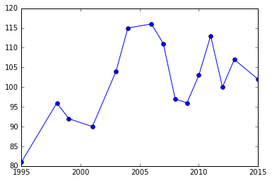

```python
fig = plt.figure()
ax = plt.axes()
ax.plot(pixar_movies["Year Released"], pixar_movies["Length (mins)"],'o-')
plt.show()
```

To draw more than one line and add legend:

[figure not shown]

```python
fig = plt.figure()
ax = plt.axes()
ax.plot(pixar_movies["Year Released"], pixar_movies["Metacritic Score (max 100)"],'o-', label="Metacritic Score (max 100)")
ax.plot(pixar_movies["Year Released"], pixar_movies["RT Score (max 100)"], label="RT Score (max 100)")

ax.set_xlabel("Year released")
ax.set_ylabel("Score")

plt.legend(loc="lower left")
plt.show()
```

plots side by side

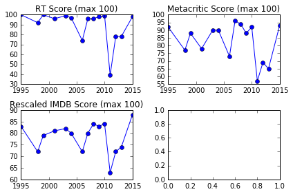

```python
fig, axs = plt.subplots(2, 2)
axs[0][0].plot(pixar_movies["Year Released"], pixar_movies["RT Score (max 100)"],'o-')
axs[0][1].plot(pixar_movies["Year Released"], pixar_movies["Metacritic Score (max 100)"],'o-')
axs[1][0].plot(pixar_movies["Year Released"], pixar_movies["Rescaled IMDB Score (max 100)"],'o-')

axs[0][0].set_title("RT Score (max 100)")
axs[0][1].set_title("Metacritic Score (max 100)")
axs[1][0].set_title("Rescaled IMDB Score (max 100)")

plt.tight_layout()
```

plot a bar chart

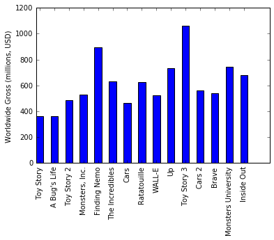

```python
fig, ax = plt.subplots()
ind = np.arange(len(pixar_movies["Movie"]))
width = 0.5
ax.bar(ind, pixar_movies["Worldwide Gross (millions, USD)"], width)
ax.set_xticks(ind + 0.5 * width)
ax.set_xticklabels(pixar_movies["Movie"].values, rotation=90)
ax.set_ylabel("Worldwide Gross (millions, USD)")
```

Now let's have a look what would happen if we import seaborn

```python
import seaborn as sns
```

Following cells are exactly the same as preivous cells

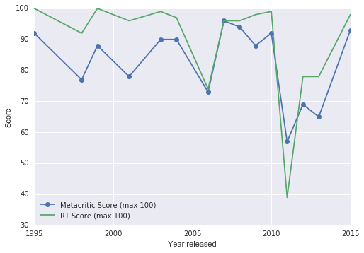

```python
fig = plt.figure()
ax = plt.axes()
ax.plot(pixar_movies["Year Released"], pixar_movies["Metacritic Score (max 100)"],'o-', label="Metacritic Score (max 100)")
ax.plot(pixar_movies["Year Released"], pixar_movies["RT Score (max 100)"], label="RT Score (max 100)")

ax.set_xlabel("Year released")
ax.set_ylabel("Score")

plt.legend(loc="lower left")
plt.show()
```

plots side by side

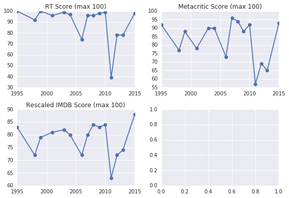

```python
fig, axs = plt.subplots(2, 2)
axs[0][0].plot(pixar_movies["Year Released"], pixar_movies["RT Score (max 100)"],'o-')
axs[0][1].plot(pixar_movies["Year Released"], pixar_movies["Metacritic Score (max 100)"],'o-')
axs[1][0].plot(pixar_movies["Year Released"], pixar_movies["Rescaled IMDB Score (max 100)"],'o-')

axs[0][0].set_title("RT Score (max 100)")
axs[0][1].set_title("Metacritic Score (max 100)")
axs[1][0].set_title("Rescaled IMDB Score (max 100)")

plt.tight_layout()
plt.show()
```

plot a bar chart

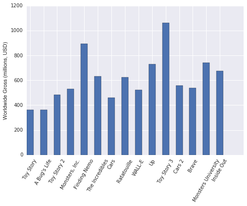

```python
fig, ax = plt.subplots()
ind = np.arange(len(pixar_movies["Movie"]))
width = 0.5
ax.bar(ind, pixar_movies["Worldwide Gross (millions, USD)"], width)
ax.set_xticks(ind + 0.5 * width)
ax.set_xticklabels(pixar_movies["Movie"].values, rotation=60)
ax.set_ylabel("Worldwide Gross (millions, USD)")

plt.show()
```

As we can see, the style of plots is totally different. Importing seaborn will overwrite matplotlib's default setting.

```python
ratio_inflation = pixar_movies["Adjusted Production Budget (millions, USD)"] / pixar_movies["Production Budget (millions, USD)"]
ratio_ticketprice = pixar_movies["Adjusted Domestic Gross (millions, USD)"] / pixar_movies["Domestic Gross (millions, USD)"]
```

Now lets visualize the difference of using ticket price and consumer price to adjust data.

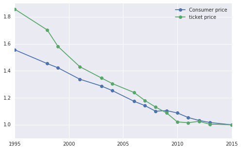

```python
fig, ax = plt.subplots(figsize=(8, 5))
ax.plot(pixar_movies["Year Released"], ratio_inflation, 'o-', label="Consumer price")
ax.plot(pixar_movies["Year Released"], ratio_ticketprice, 'o-', label="ticket price")
plt.legend()
```

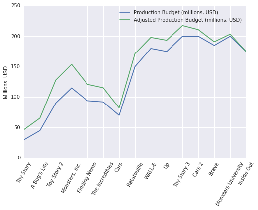

```python
# compare the difference between adjusted and non-adjusted production budget
fig, ax = plt.subplots()

ax.plot(pixar_movies["Production Budget (millions, USD)"], label="Production Budget (millions, USD)")
ax.plot(pixar_movies["Adjusted Production Budget (millions, USD)"], label="Adjusted Production Budget (millions, USD)")

ax.set_xticks(pixar_movies.index)
ax.set_xticklabels(pixar_movies["Movie"], rotation=60)
ax.set_ylabel('Millions, USD')
ax.legend()

plt.show()
```

As we can see above. To fairly compare the money each movie spent we need to adjust older movies to a higher budget.

```python
# make the movie column be the indices
pixar_movies.set_index('Movie', inplace=True)
```

Now lets visualize the the score each movie got on different review websites.

```python
critics_reviews = pixar_movies[["RT Score (max 100)", "Rescaled IMDB Score (max 100)", "Metacritic Score (max 100)"]]
```

```python
critics_reviews
```

| Movie | RT Score (max 100) | Rescaled IMDB Score (max 100) | Metacritic Score (max 100) |
| --- | --- | --- | --- |
| Toy Story | 100 | 83.0 | 92 |
| A Bug's Life | 92 | 72.0 | 77 |
| Toy Story 2 | 100 | 79.0 | 88 |
| Monsters, Inc. | 96 | 81.0 | 78 |
| Finding Nemo | 99 | 82.0 | 90 |
| The Incredibles | 97 | 80.0 | 90 |
| Cars | 74 | 72.0 | 73 |
| Ratatouille | 96 | 80.0 | 96 |
| WALL-E | 96 | 84.0 | 94 |
| Up | 98 | 83.0 | 88 |
| Toy Story 3 | 99 | 84.0 | 92 |
| Cars 2 | 39 | 63.0 | 57 |
| Brave | 78 | 72.0 | 69 |
| Monsters University | 78 | 74.0 | 65 |
| Inside Out | 98 | 88.0 | 93 |

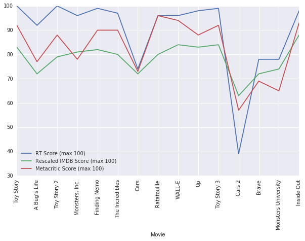

```python
fig = critics_reviews.plot(figsize=(10, 6))
plt.xticks(np.arange(15), critics_reviews.index, rotation='vertical')
plt.show()
```

A good way to spot the outliers is using box plot. However, while using seaborn to get a better style, one may not be able to see the outlier if the plot is done by the dataframe method.

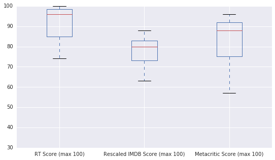

```python
# box plot without specifying the symbol
critics_reviews.plot(kind="box", figsize=(9, 5))
```

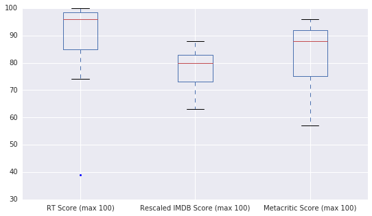

```python
# box plot with symbol specified
critics_reviews.plot(kind="box", figsize=(9, 5), sym="k.")
```

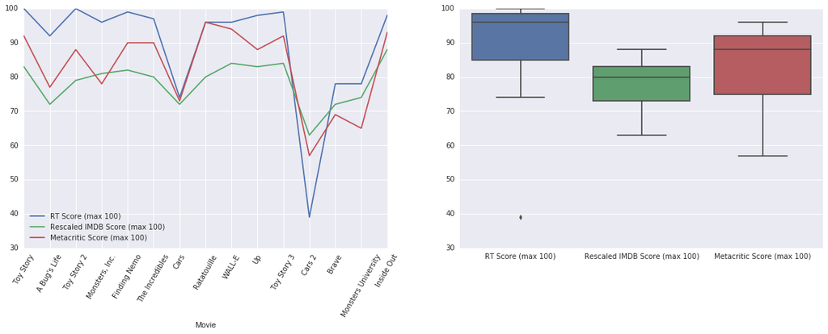

```python
fig, axs = plt.subplots(1, 2, figsize=(20, 6))
critics_reviews.plot(ax=axs[0])
sns.boxplot(data=critics_reviews)


axs[0].set_xticks(range(0, critics_reviews.shape[0]), minor=False)
axs[0].set_xticklabels(critics_reviews.index, rotation=60)

plt.show()
```

It is clear that cars2 is the outlier and it is production budget is the second highest.

```python
pixar_movies.sort_values('Adjusted Production Budget (millions, USD)', ascending=False)["Adjusted Production Budget (millions, USD)"]
```

```
Movie
Toy Story 3            217.535060
Cars 2                 210.789787
Monsters University    203.403200
WALL-E                 198.118403
Up                     193.388669
Brave                  190.970179
Inside Out             175.000000
Ratatouille            171.372419
Monsters, Inc.         153.844028
Toy Story 2            127.979075
Finding Nemo           120.987726
The Incredibles        115.300408
Cars                    82.213062
A Bug's Life            65.397307
Toy Story               46.674016
Name: Adjusted Production Budget (millions, USD), dtype: float64
```

Now we can have a look of the trend of the revenue percentage of pixar movies

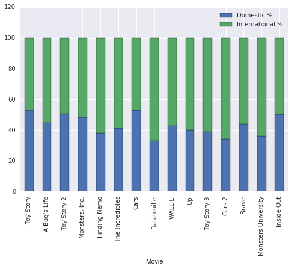

```python
pixar_movies = pixar_movies.sort_values(["Year Released"], ascending=True)

revenue_proportions = pixar_movies[["Domestic %", "International %"]]

revenue_proportions.plot(kind="bar", stacked=True)
```

It is not quite clear through the stack plot above since it contains no time and also the difference is not obvious to human eyes.

We use scatter plot to released year against domestic percentage to make the trend clear.

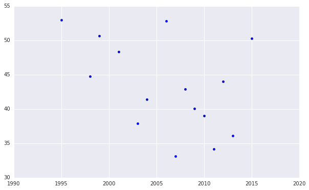

```python
fig, ax = plt.subplots(figsize=(10, 6))

ax.scatter(pixar_movies['Year Released'], pixar_movies['Domestic %'])

plt.show()
```

To get a better idea, we can quantify it via linear regression and p value

```python
from scipy import stats
```

```python
slope, intercept, r_value, p_value, std_err = stats.linregress(pixar_movies['Year Released'], pixar_movies['Domestic %'])
```

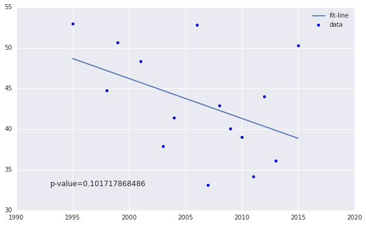

```python
fig, ax = plt.subplots(figsize=(10, 6))

ax.scatter(pixar_movies['Year Released'], pixar_movies['Domestic %'], label='data')
ax.plot(pixar_movies['Year Released'], slope * pixar_movies['Year Released'] + intercept, label='fit-line')
ax.legend()

ax.text(1993, 33, 'p-value={}'.format(p_value))
plt.show()
```

If we are interesting in knowing what correlated to Oscar award most, we can compute the correlation matrix and extract the column of Oscar reward. However, since the result of inside out was not announced by the time of this data, we will filter it out by using dropna.

```python
filter_movies = pixar_movies.dropna(axis=0)
```

```python
cols = list(filter_movies.columns)
```

```python
cols
```

```
['Year Released',
 'Length (mins)',
 'RT Score (max 100)',
 'Rescaled IMDB Score (max 100)',
 'Metacritic Score (max 100)',
 'Opening Weekend (millions, USD)',
 'Worldwide Gross (millions, USD)',
 'Domestic Gross (millions, USD)',
 'Adjusted Domestic Gross (millions, USD)',
 'International Gross (millions, USD)',
 'Domestic %',
 'International %',
 'Production Budget (millions, USD)',
 'Oscars Nominated',
 'Oscars Won',
 'Adjusted Production Budget (millions, USD)',
 'Adjusted Opening Weekend (millions, USD)']
```

```python
cols.remove('Production Budget (millions, USD)')
cols.remove('Opening Weekend (millions, USD)')
cols.remove('Domestic Gross (millions, USD)')
```

```python
abs_corr = pixar_movies[cols].corr().abs()
```

```python
abs_corr['Oscars Nominated'].sort_values(ascending=False)
```

```
Oscars Nominated                              1.000000
Metacritic Score (max 100)                    0.838883
Rescaled IMDB Score (max 100)                 0.817596
Oscars Won                                    0.734945
RT Score (max 100)                            0.632767
Worldwide Gross (millions, USD)               0.384349
International Gross (millions, USD)           0.352585
Adjusted Domestic Gross (millions, USD)       0.325413
Domestic %                                    0.142666
International %                               0.142492
Adjusted Production Budget (millions, USD)    0.133470
Adjusted Opening Weekend (millions, USD)      0.078044
Length (mins)                                 0.069799
Year Released                                 0.014485
Name: Oscars Nominated, dtype: float64
```

```python
abs_corr['Oscars Won'].sort_values(ascending=False)
```

```
Oscars Won                                    1.000000
Oscars Nominated                              0.734945
Worldwide Gross (millions, USD)               0.621834
International Gross (millions, USD)           0.582735
Rescaled IMDB Score (max 100)                 0.575408
Metacritic Score (max 100)                    0.503676
RT Score (max 100)                            0.438174
Adjusted Production Budget (millions, USD)    0.401986
Domestic %                                    0.333284
International %                               0.333149
Adjusted Domestic Gross (millions, USD)       0.311573
Year Released                                 0.296232
Adjusted Opening Weekend (millions, USD)      0.257942
Length (mins)                                 0.125731
Name: Oscars Won, dtype: float64
```

As we can see that the number of Oscar nominations is correlated with the review scores, and the number of Oscard awards might correlated with the Worldwide Gross where the highest correlated Oscars nomination is trivial. One can also apply linear regression method we used before to see if a linear relation really exist between Oscar and other features.

Note that this is only for the case of Pixar's movie which cannot be trivially generalized to all other movies. Also, the correlation does not guarantee causality.

The goal of this note is just for learning and showing the data science relevant functions.

```python
os.system('jupyter nbconvert --to html Pixar_Movie.ipynb')
```

```
0
```